# Investigate Predictiveness of Luminex Layer

Now that we have our imputation method, we can see if the luminex layer helps AUC, without looking at a benchmark that is reduced in terms of drugs.

```r
knitr::opts_knit$set(root.dir=normalizePath("../../"))
```

## Load Data

Get all necessary imports and functions

```r
rm(list=ls())

set.seed(9833)

library(ROCR)
library(reshape2)
library(caret)
library(SNFtool)
library(org.Hs.eg.db)
library(missForest)
library(doParallel)

source("RCode/flexible_layers/sensitivityDataFlexible.R")
source("RCode/flexible_layers/perturbationDataFlexible.R")
source("RCode/flexible_layers/perturbationDataFlexibleCustomSig.R")
source("RCode/flexible_layers/structureDataFlexible.R")
source("RCode/flexible_layers/luminexDataFlexible.R")

source("RCode/flexible_layers/constLuminexLayerFlexible.R")
source("RCode/flexible_layers/constSensitivityLayerFlexible.R")
source("RCode/flexible_layers/constPerturbationLayerFlexible.R")
source("RCode/flexible_layers/constStructureLayerFlexible.R")

source("RCode/cindexComp2.R")
source("RCode/flexible_layers/compConcordIndxFlexible.R")
source("RCode/flexible_layers/generateDrugPairsFlexible.R")
source("RCode/flexible_layers/drugTargetBenchFlexible.R")
source("RCode/flexible_layers/compDrugTargetBenchmarkFlexible.R")
source("RCode/flexible_layers/stackedLayerAnalysisHelpers.R")
source("RCode/flexible_layers/printCIndices.R")
source("RCode/flexible_layers/printPVals.R")
source("RCode/flexible_layers/generateROCPlotFlexible.R")
source("RCode/predPerf.R")
source("RCode/value_inference_models/modifying_snf/snfModifiedHelpers.R")

source("RCode/goldenberg_imputation/medianSimilarity.R")

badchars <- "[\xb5]|[\n]|[,]|[;]|[:]|[-]|[+]|[*]|[%]|[$]|[#]|[{]|[}]|[[]|[]]|[|]|[\\^]|[/]|[\\]|[.]|[_]|[ ]"
```

Load LINCS metadata file. Used it contains the smiles string for the drugs in the perturbation layer. These are then used to construct the structure layer.

```r
lincs.meta <- read.csv("Data/LINCS.csv", stringsAsFactors = FALSE)
lincs.meta$pert_iname <- toupper(lincs.meta$pert_iname)
lincs.meta$pert_iname <- gsub(badchars, "", lincs.meta$pert_iname)
```

Load in senstivity, luminex data as well as perturbation signatures

```r
pert.file.name <- "Data/pert_sigs_6_hour/pert_features_full.RData"
sensitivity.file.name <- "Data/combined_sensitivity//combined_sens_iname_replaced.RData"
luminex.file.name <- "Data/luminex_processed/luminex_50_pca.rds"

sens.data <- SensitivityDataFlexible(sensitivity.file.name)  ## 645 X 239
pert.data <- PerturbationDataFlexibleCustomSig(pert.file.name)  ## 978 X 23
luminex.data <- LuminexDataFlexible(badchars, luminex.file.name)

luminex.data <- luminex.data[, colnames(luminex.data) %in% colnames(sens.data)]
```

Subset the lincs metadata file to only the drugs appearing in the sensitivity layer

```r
sens.names <- rownames(sens.data)

lincs.meta.subset <- lincs.meta[match(sens.names, lincs.meta$pert_iname),]
lincs.meta.subset <- lincs.meta.subset[!is.na(lincs.meta.subset$X),]
```

Now we create the structure fingerprints based on the subsetted lincs metadata

```r
strc.data <- StructureDataFlexible(lincs.meta.subset)  ## a vector  --> 239 elemnts
```

## Find Common Drugs

Now to find the drugs that are common between all layers

Now we can choose the layers to be used in the integration and see the drugs that are common between them. Leave out pert names from the intersection since we know that the pert layer is missing 8 drugs compared to the strc layer, so we’ll use our imputation method to get a full integrated network of 365 drugs instead of 357 drugs.

```r
layers <- list(sens.names = sort(colnames(sens.data)),
               strc.names = names(strc.data))
common.drugs <- Reduce(intersect, Filter(Negate(is.null),layers))
print(length(common.drugs))
```

```
## [1] 365
```

## Create Similarities

```r
strc.cor <- fingerprint::fp.sim.matrix(strc.data, method = "tanimoto")
colnames(strc.cor) <- names(strc.data)
rownames(strc.cor) <- names(strc.data)

strc.cor <- strc.cor[common.drugs, common.drugs]

luminex.cor <- ConstLuminexLayerFlexible(luminex.data)
pert.cor <- cor(pert.data[, intersect(common.drugs, colnames(pert.data))], method="pearson", use="pairwise.complete.obs")

registerDoParallel(4)
# Impute missing data
pert.cor <- missForest(pert.cor, maxiter=10, parallelize = "variables")$ximp
```

```
##   missForest iteration 1 in progress...done!
##   missForest iteration 2 in progress...done!
##   missForest iteration 3 in progress...done!
##   missForest iteration 4 in progress...done!
```

```r
sens.cor <- sens.data[common.drugs, common.drugs]
```

## Integrate Network

```r
all.drugs <- common.drugs

correlation.matrices <- list(sens=sens.cor, pert=pert.cor, strc=strc.cor, luminex=luminex.cor)

affinity.matrices <- CreateAffinityMatrices(correlation.matrices)
augmented.matrices <- CreateAugmentedMatrixSkeletons(names(correlation.matrices), all.drugs)
augmented.matrices <- ReplaceAugmentedExistingValues(augmented.matrices, affinity.matrices)
affinity.matrices <- ReplaceAffinityMatrixValuesFast(augmented.matrices, correlation.matrices,
                                                     all.drugs)
affinity.matrices <- medianSimilarity(affinity.matrices)

integrated <- SNFtool::SNF(affinity.matrices)
rownames(integrated) <- all.drugs
colnames(integrated) <- all.drugs
```

## Evaluate Performance With luminex

### On CTRPv2 Drug Target Dataset

```r
CompDrugTargetBenchmarkFlexible(common.drugs=common.drugs, gmt.file.name="temp",
                                strc.aff.mat=affinity.matrices$strc,
                                sens.aff.mat=affinity.matrices$sens, pert.aff.mat=affinity.matrices$pert,
                                integration=integrated, luminex.aff.mat=affinity.matrices$luminex,
                                imaging.aff.mat=NULL, target.roc.file.name="blessed_roc.pdf",
                                use.ctrpv2=TRUE, use.clue=FALSE, use.chembl=FALSE,
                                use.dbank=FALSE, use.dtc=FALSE)
```

```
## [1] "Benchmark obtained"
## [1] "Drug pairs obtained"
## [1] "Concordance Index computed"
## c.indices values from each layer vs. the benchmark:
## strcCindex: 0.6964124
## sensCindex: 0.8837202
## pertCindex: 0.7450214
## integrCindex: 0.9387028
## luminexCindex: 0.8812102
## p-vals from the c.index comparison of integration layer vs.
## strcPVal: 1.430918e-65
## sensPVal: 7.609647e-08
## pertPVal: 1.486399e-52
## luminexPVal: 3.840272e-10
```

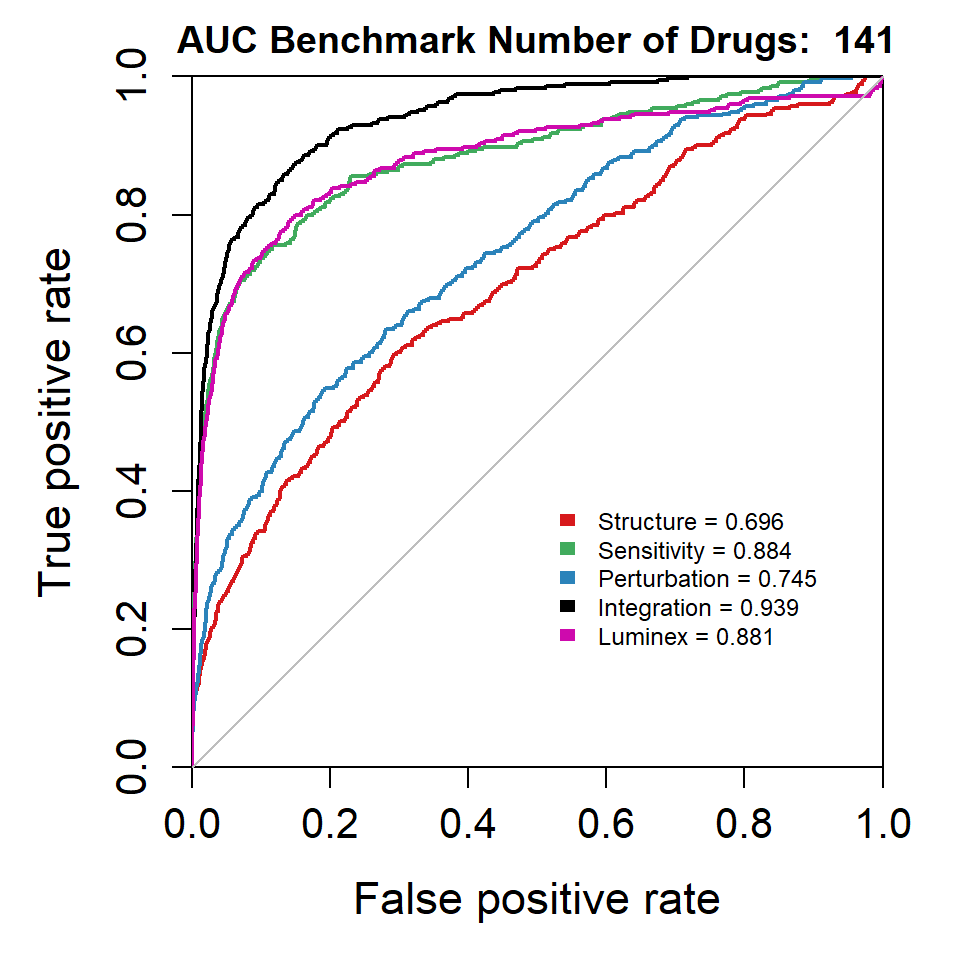

### On Combined CTRPv2, CLUE, CHEMBL Drug Target Dataset

```r
CompDrugTargetBenchmarkFlexible(common.drugs=common.drugs, gmt.file.name="temp",
                                strc.aff.mat=affinity.matrices$strc,
                                sens.aff.mat=affinity.matrices$sens, pert.aff.mat=affinity.matrices$pert,
                                integration=integrated, luminex.aff.mat=affinity.matrices$luminex,
                                imaging.aff.mat=NULL, target.roc.file.name="blessed_roc.pdf",
                                use.ctrpv2=TRUE, use.clue=TRUE, use.chembl=TRUE,
                                use.dbank=TRUE, use.dtc=FALSE)
```

```
## [1] "Benchmark obtained"
## [1] "Drug pairs obtained"
## [1] "Concordance Index computed"
## c.indices values from each layer vs. the benchmark:
## strcCindex: 0.6801962
## sensCindex: 0.7193568
## pertCindex: 0.6765949
## integrCindex: 0.8397997
## luminexCindex: 0.7722098
## p-vals from the c.index comparison of integration layer vs.
## strcPVal: 1.062655e-72
## sensPVal: 4.675141e-34
## pertPVal: 8.077158e-66
## luminexPVal: 2.651362e-20
```

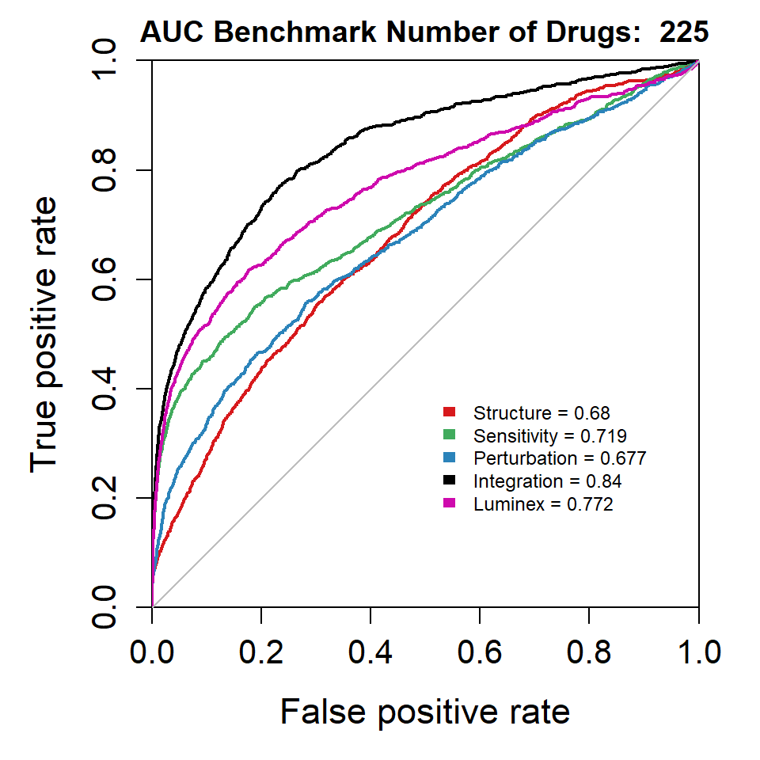

## Evaluate Performance Without luminex

First, we have to recreate the network with the luminex layer removed

```r
all.drugs <- common.drugs

correlation.matrices <- list(sens=sens.cor, pert=pert.cor, strc=strc.cor)

affinity.matrices <- CreateAffinityMatrices(correlation.matrices)
augmented.matrices <- CreateAugmentedMatrixSkeletons(names(correlation.matrices), all.drugs)
augmented.matrices <- ReplaceAugmentedExistingValues(augmented.matrices, affinity.matrices)
affinity.matrices <- ReplaceAffinityMatrixValuesFast(augmented.matrices, correlation.matrices,
                                                     all.drugs)
affinity.matrices <- medianSimilarity(affinity.matrices)

integrated <- SNFtool::SNF(affinity.matrices)
rownames(integrated) <- all.drugs
colnames(integrated) <- all.drugs
```

### On CTRPv2 Drug Target Dataset

```r
CompDrugTargetBenchmarkFlexible(common.drugs=common.drugs, gmt.file.name="temp",
                                strc.aff.mat=affinity.matrices$strc,
                                sens.aff.mat=affinity.matrices$sens, pert.aff.mat=affinity.matrices$pert,
                                integration=integrated, luminex.aff.mat=NULL,
                                imaging.aff.mat=NULL, target.roc.file.name="blessed_roc.pdf",
                                use.ctrpv2=TRUE, use.clue=FALSE, use.chembl=FALSE,
                                use.dbank=FALSE, use.dtc=FALSE)
```

```
## [1] "Benchmark obtained"
## [1] "Drug pairs obtained"
## [1] "Concordance Index computed"
## c.indices values from each layer vs. the benchmark:
## strcCindex: 0.6964124
## sensCindex: 0.8837202
## pertCindex: 0.7450214
## integrCindex: 0.9326206
## p-vals from the c.index comparison of integration layer vs.
## strcPVal: 9.676104e-64
## sensPVal: 2.325968e-06
## pertPVal: 2.627119e-50
```

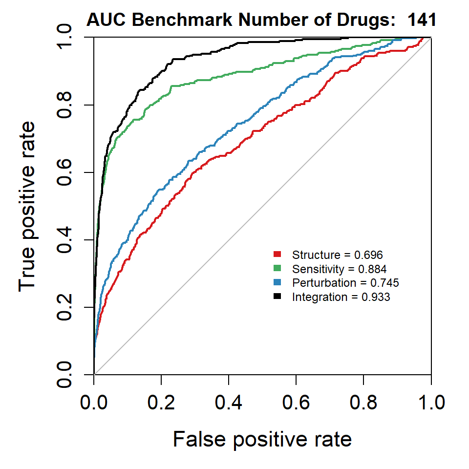

### On Combined CTRPv2, CLUE, CHEMBL Drug Target Dataset

```r
CompDrugTargetBenchmarkFlexible(common.drugs=common.drugs, gmt.file.name="temp",
                                strc.aff.mat=affinity.matrices$strc,
                                sens.aff.mat=affinity.matrices$sens, pert.aff.mat=affinity.matrices$pert,
                                integration=integrated, luminex.aff.mat=NULL,
                                imaging.aff.mat=NULL, target.roc.file.name="blessed_roc.pdf",
                                use.ctrpv2=TRUE, use.clue=TRUE, use.chembl=TRUE,
                                use.dbank=TRUE, use.dtc=FALSE)
```

```
## [1] "Benchmark obtained"
## [1] "Drug pairs obtained"
## [1] "Concordance Index computed"
## c.indices values from each layer vs. the benchmark:
## strcCindex: 0.6801962
## sensCindex: 0.7193568
## pertCindex: 0.6765949
## integrCindex: 0.8304745
## p-vals from the c.index comparison of integration layer vs.
## strcPVal: 2.86397e-66
## sensPVal: 3.841716e-28
## pertPVal: 2.350841e-60
```

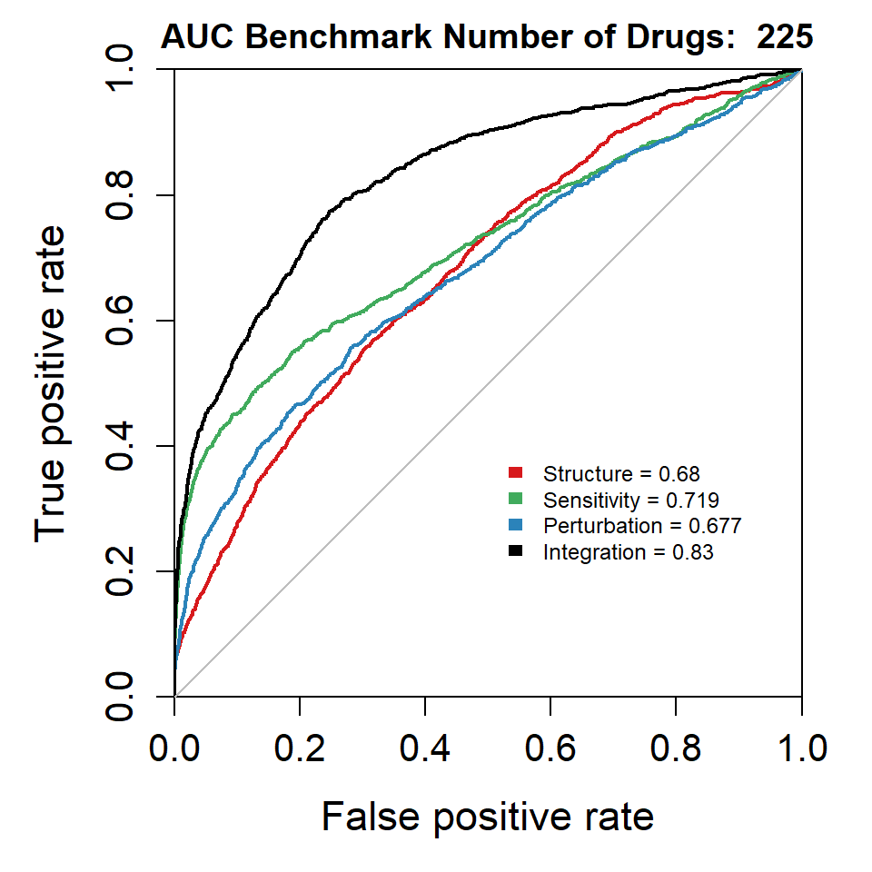

## Conclusion

As can be seen in the above plots, there is no significant improvement in AUC when we include the luminex layer. This suggests that the added complexity of having it as another layer is not worth the slight performance boost gain, which very well could just be noise